# Proje Rapor : Mert YILMAZ 200401098

**Hocam, öncelikle çok teşekkür ederim. Bölümümüzde şu ana kadar ilk defa kesinlikle bu kadar faydalı şeyler öğrenebildiğimi ve yapabildiğimi hissediyorum. Fen Lisesi’nde öğretmenlik yapıyorum. Gerçekleştirdiğiniz eğitim rehberliğini rol model olarak II. dönem boyunca öğrencilere egzersizler vererek -aynı şekilde internet kullanımını serbest bırakarak- ilerleyeceğim. Kattığınız her şey için tekrar çok teşekkür ederim. Önümüzdeki dönem de mümkünse okulumuzda olmanızı ve seçebilmek için 4. sınıf ikinci dönemi için seçmeli dersinizin olmasını umuyorum.Esenlikler dilerim…**

# Q1 : Problem tanımı

Şirketimiz **CargoBox**. Problemimiz *Şirketimiz bir startup’dur. Bu sebeple çalışana ayıracak bütçesi kısıtlıdır. Mümkün olduğunca düşük maaşla çalışacak çalışanlara ihtiyacı vardır.Yeni bir girişim olduğu için şirketin geçmişi ve geleceği belirsizdir. Bu sebeple bir girişimde yer almak isteyecek, girişimci ruhu bulunan çalışanlar olmalıdır.*.

# Q2 : Proje Amacı

[Entrepreneurial Competency in University Students](https://www.kaggle.com/datasets/namanmanchanda/entrepreneurial-competency-in-university-students) adlı girişimci üniversite öğrencilerine ilişkin Kaggle veri seti ile İkinci bir veri seti olarak şirketimin departman adlarını ve departmanlarının üniversitelerin hangi bölümlerinden çalışanlar aradıkları gibi değişkenler içeren basit bir (https://drive.google.com/file/d/11d_qbho-N2cZz1ORmWvCrIRo2aQVVvtn/view?usp=sharing) veri setini *girişimci olan adayları filtreleyerek* ve *girişimci olan adayları bölümlerine göre kümeleyerek* ardından *adayların pozitif özelliklerinin toplamından negatif özelliklerinin toplamı ile sentetik veri oluşturulması sonucu adayların sıralanması* ve ikinci veri setinde **alım şartlarını sağlayan adayların belirlenmesi** yöntemlerini kullanarak problemi yok edeceğiz. Bu sayede de iş için uygun adayları belirlemeyi planlıyoruz.

# Q3 : Veri seti keşifsel analizi

Veri setlerinin bilgileri aşağıda verilmiştir.

**Entrepreneurial Competency in University Students Dataset** - **Satir sayisi** : 219 - **Sütun sayisi** : 17

**departmanların ihtiyaçları Dataset** - **Satir sayisi** : 7 - **Sütun sayisi** : 4

Veri setlerinin görselleştirmesi aşağıda verilmiştir.

**Entrepreneurial Competency in University Students Dataset**

| EducationSector | IndividualProject | Age | Gender | City | Influenced | Perseverance | DesireToTakeInitiative | Competitiveness | SelfReliance | StrongNeedToAchieve | SelfConfidence | GoodPhysicalHealth | MentalDisorder | KeyTraits | ReasonsForLack | y |
| --- | --- | --- | --- | --- | --- | --- | --- | --- | --- | --- | --- | --- | --- | --- | --- | --- |
| Engineering Sciences | No | 19 | Male | Yes | No | 2 | 2 | 3 | 3 | 2 | 2 | 3 | Yes | Passion | NA | 1 |
| Engineering Sciences | Yes | 22 | Male | No | Yes | 3 | 3 | 3 | 4 | 4 | 3 | 4 | Yes | Vision | Just not interested! (Want to work in the corporate sector, or for the government or pursue research or something else) | 0 |
| Engineering Sciences | No | 18 | Male | Yes | No | 3 | 4 | 3 | 3 | 3 | 4 | 4 | No | Passion | Not willing to start a venture in India and waiting for future relocation | 0 |
| Engineering Sciences | Yes | 20 | Male | Yes | Yes | 3 | 3 | 3 | 3 | 4 | 3 | 3 | No | Resilience | Not able to take a Financial Risk | 0 |
| Engineering Sciences | Yes | 19 | Male | Yes | Yes | 2 | 3 | 3 | 3 | 4 | 3 | 2 | Yes | Vision | NA | 1 |
| Engineering Sciences | No | 19 | Male | Yes | Yes | 3 | 3 | 3 | 3 | 3 | 3 | 3 | No | Positivity | NA | 1 |
| Engineering Sciences | Yes | 19 | Male | Yes | Yes | 3 | 2 | 3 | 3 | 4 | 1 | 1 | No | Work Ethic | NA | 1 |
| Engineering Sciences | No | 20 | Male | Yes | Yes | 4 | 2 | 4 | 4 | 5 | 3 | 4 | Yes | Work Ethic | Just not interested! (Want to work in the corporate sector, or for the government or pursue research or something else), Academic Pressure, Lack of Knowledge, Not able to take a Financial Risk | 0 |
| Others | Yes | 20 | Male | Yes | Yes | 2 | 3 | 3 | 1 | 2 | 2 | 2 | No | Passion | Academic Pressure, Lack of Knowledge, Not able to take a Financial Risk | 0 |
| Engineering Sciences | Yes | 17 | Male | Yes | Yes | 2 | 3 | 2 | 1 | 4 | 3 | 3 | Yes | Work Ethic | NA | 1 |

[output cut: 209 more lines]

**departmanların ihtiyaçları Dataset**

| Departments | RequireEducationSector | EmployeeCount | RequireInternCount |
| --- | --- | --- | --- |
| Production, research and development department | Engineering Sciences | 5 | 3 |
| Accounting and finance departments | Economic Sciences, Business Studies, Commerce and Law | 3 | 3 |
| Sales | Economic Sciences, Business Studies, Commerce and Law | 6 | 3 |
| Marketing department | Mathematics or Natural Sciences or Economic Sciences, Business Studies, Commerce and Law | 4 | 4 |
| Information technology department | Language and Cultural Studies or Engineering Sciences | 7 | 1 |
| Operations management department | Engineering Sciences or Economic Sciences, Business Studies, Commerce and Law | 6 | 3 |
| Human resources | Economic Sciences, Business Studies, Commerce and Law | 5 | 2 |

Veri setlerini incelediğimizde, problem çözümü için “Entrepreneurial Competency in University Students Dataset” tablomuzdan gerçekleştireceğimiz filtreleme işlemi için kullanabileceğimiz sütunların öğrencinin daha önce proje yapıp/yapmadığını gösteren **IndividualProject** sütunu ile öğrencinin mental sağlığının bozuk olup/olmadığını gösteren **MentalDisorder** sütunlarında karakter veri tipi olduğunu görüyoruz. Yine aynı tabloda yer alan **EducationalSector** karakter veri tipi içeren sütununa bağlı olarak kümeleme işlemi gerçekleştirerceğiz. Yine aynı veri setinde yer alan **Perseverance**, **DesireToTakeInitiative**, **Competitiveness**, **SelfReliance**, **StrongNeedToAchieve**, **SelfConfidence**, **GoodPhysicalHealth** sütunlarında sayı veri tipinde yer alan skorlar toplanarak girişimcilik skoru belirlenecektir. Diğer sütunlardaki değişkenlere ihtiyaç duymayacağımızdan onları sileceğiz / dikkate almayacağız.

Adayların kaç tanesinin daha önce bir proje gerçekleştirip gerçekleştirmediği aşağıda verilmiştir. Çoğunun daha önce bir projede yer aldığı görülmüştür.

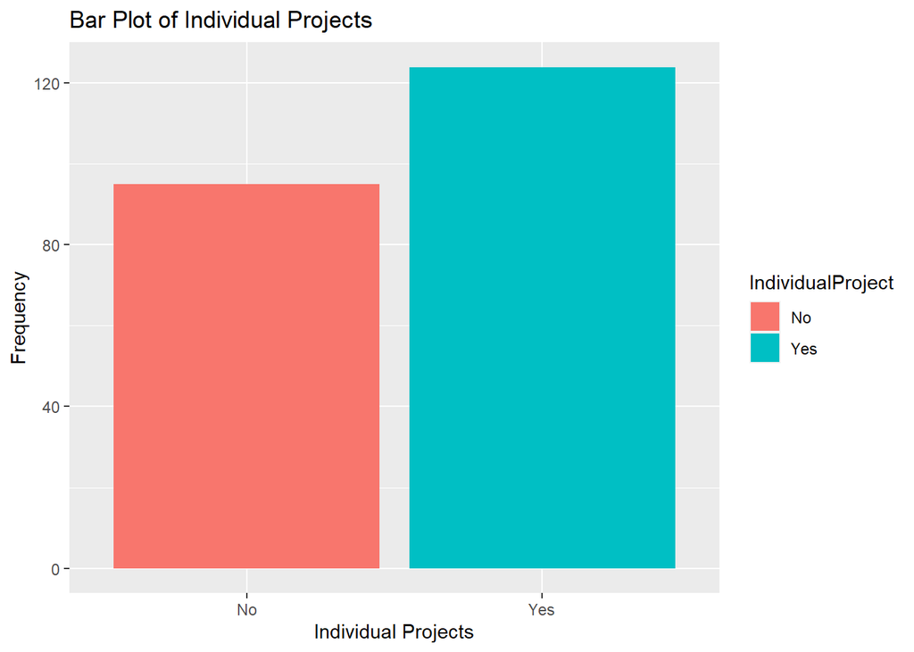

Adayların kaç tanesinin mental bir rahatsızlığı olup olmadığı aşağıda belirtilmiştir. Çoğunun mental bir rahatsızlığının olmadığı görülmüştür.

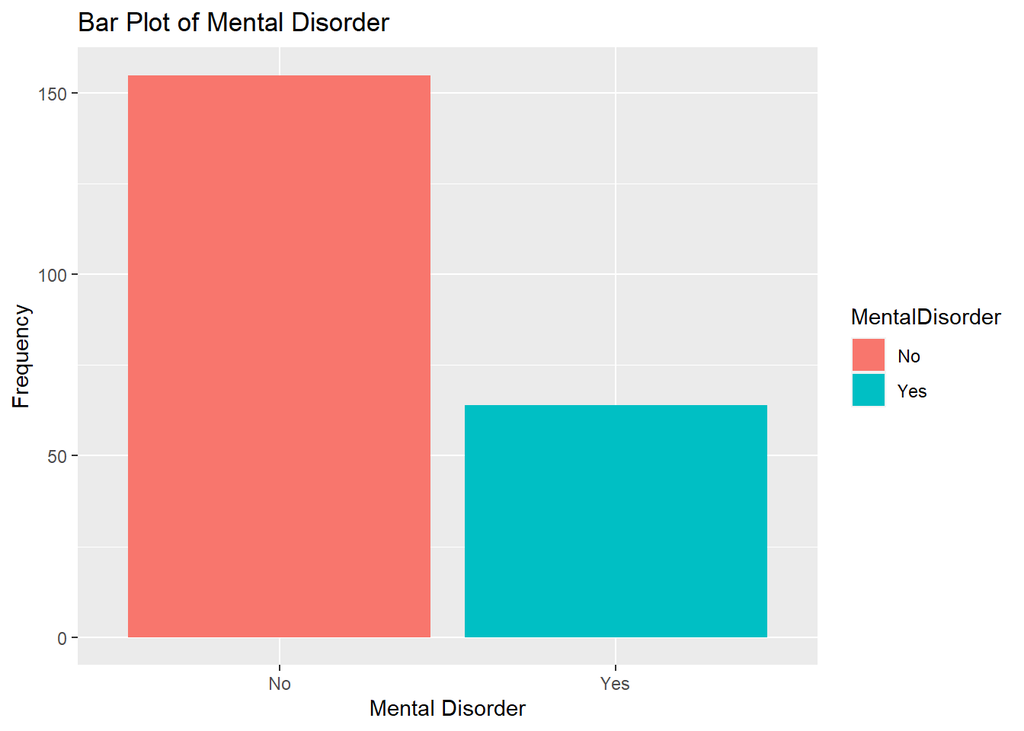

Daha önce proje gerçekleştirmiş ve mental bir rahatsızlığı olmayan dayların bölümlerine göre dağılımları gösterilmiştir. Çoğunun Mühendislik öğrencisi olduğu görülmüştür.

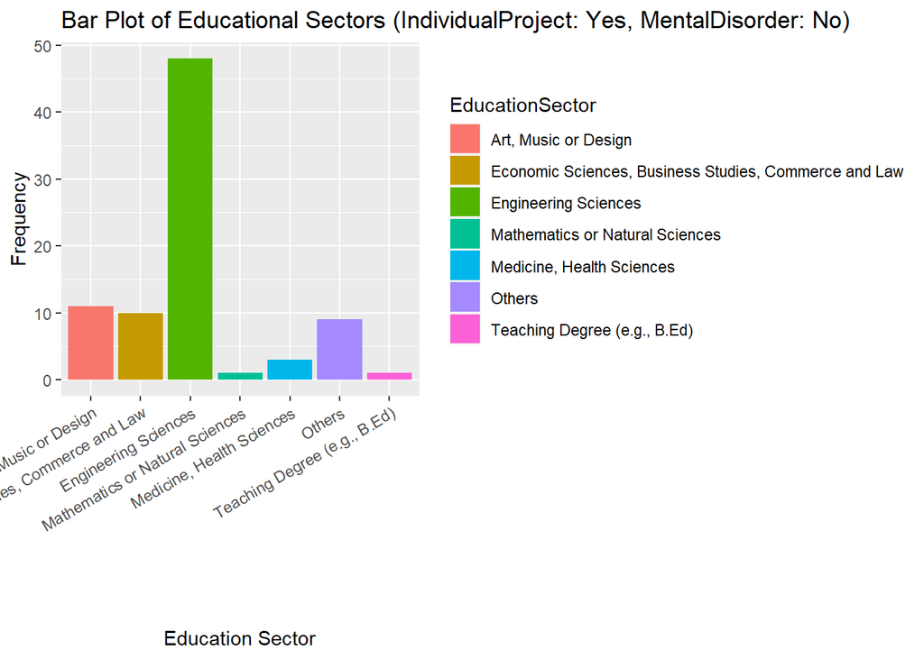

# Bu R CHUNK, test kodlarını içerir

```
##
[ FAIL 0 | WARN 0 | SKIP 0 | PASS 0 ]
[ FAIL 0 | WARN 0 | SKIP 0 | PASS 1 ]
[ FAIL 0 | WARN 0 | SKIP 0 | PASS 2 ]
[ FAIL 0 | WARN 0 | SKIP 0 | PASS 3 ]
[ FAIL 0 | WARN 0 | SKIP 0 | PASS 4 ]
[ FAIL 0 | WARN 0 | SKIP 0 | PASS 5 ]
[ FAIL 0 | WARN 0 | SKIP 0 | PASS 6 ]
```

```
##
[ FAIL 0 | WARN 0 | SKIP 0 | PASS 0 ]
[ FAIL 0 | WARN 0 | SKIP 0 | PASS 1 ]
[ FAIL 0 | WARN 0 | SKIP 0 | PASS 2 ]
[ FAIL 0 | WARN 0 | SKIP 0 | PASS 3 ]
[ FAIL 0 | WARN 0 | SKIP 0 | PASS 4 ]
[ FAIL 0 | WARN 0 | SKIP 0 | PASS 5 ]
[ FAIL 0 | WARN 0 | SKIP 0 | PASS 6 ]
```

```
##
[ FAIL 0 | WARN 0 | SKIP 0 | PASS 0 ]
[ FAIL 0 | WARN 0 | SKIP 0 | PASS 1 ]
[ FAIL 0 | WARN 0 | SKIP 0 | PASS 2 ]
[ FAIL 0 | WARN 0 | SKIP 0 | PASS 3 ]
[ FAIL 1 | WARN 0 | SKIP 0 | PASS 3 ]
##
## ── Failure ('Q3_tests_mert_yılmaz_200401098.R:18:3'):  myDF_2 adlı data.framenin   sütun sayısını 8 mi ? ──
## ncol(myDF_2) not equal to 5.
## 1/1 mismatches
## [1] 4 - 5 == -1
##
[ FAIL 1 | WARN 0 | SKIP 0 | PASS 3 ]
```